# **Final Tutorial: An Analysis on the Top Twitch Streamers**

#### Shreya Thakur, Seth Amballa

1. Introduction and Background
2. Motivation
3. Data Set-Up
4. Preliminary Analysis
5. Top 25 Streamers Vs...
6. Looking at Top 10 Streamers
7. Stream Time of Top 100 Streamers
8. Bottom 100 Streamers
9. Linear Regression of All Streamers
10. Conclusion

## **Introduction & Background:**

Our data science tutorial is built around the data regarding the top streamers on Twitch. Our tutorial provides various analyses regarding streaming minutes, viewers, and followers of these top streamers.

Gaming has always been a huge industry and each year it only grows bigger. Every year millions of dollars are invested into various games and gaming platforms and the revenue is massive. Twitch is a live streaming video service, mainly popular for their video game live streams. Twitch has been used to broadcast ESports comptitions, as well as music broadcasts, and other creative content. It is a platform used by millions of people around the world and we found an analysis on it would prove useful for others wanting to learn more about this industry.

## **Motivation**:

During 2020 as Covid-19 swept through every nation, the world was mostly confined to their homes and in turn the popularity of Twitch only grew bigger. In February 2020, the streaming service had almost 15 million daily active users and around 3 million bradcasters. We wanted to analyze the top streamers of Twitch in 2020 to observe how various variables affect streams. Not only will this analhysis be beneficial for Twitch streamers thmselves but it will also help provide an analysis for individuals curious as to how and why streaming is so popular on Twitch. Using our data set we can determine things such as if the number of followers gained affects how much time a creator streams. Or if a streamers content rating can be beneficial for them to gain followers. All these analyses will hopefully prove to be beneficial for new and old stramers in figuring out how to improve their platform and gain followers. Twitch has continuously been a popular streaming platform so it would be extremly useful to provide an analysis using the data of the streams on this widly used service.

## **Data Set-Up:**

Our dataset for this tutorial was taken from [here](https://www.kaggle.com/aayushmishra1512/twitchdata). The data consists of various variables suchs as total viewers, active viwers, followers gained, and minutes watched along with other measures. For our data manipulation and analyses we make use of the following libraries: [pandas](https://pandas.pydata.org/pandas-docs/stable/), [numpy](https://numpy.org/doc/stable/user/), [matplotlib](https://matplotlib.org/stable/users/index.html), [seaborn](https://seaborn.pydata.org/), and others.

```python
import pandas as pd
import numpy as np
import matplotlib.pyplot as plt
from matplotlib import style
from matplotlib.pyplot import figure
from sklearn.linear_model import LinearRegression
style.use("ggplot")
import warnings
import seaborn as sns
import statsmodels.formula.api as smf
warnings.filterwarnings('ignore')
```

```python
data = pd.read_csv("./twitchdata-update.csv")
data.head()
```

|  | Channel | Watch time(Minutes) | Stream time(minutes) | Peak viewers | Average viewers | Followers | Followers gained | Views gained | Partnered | Mature | Language |
| --- | --- | --- | --- | --- | --- | --- | --- | --- | --- | --- | --- |
| 0 | xQcOW | 6196161750 | 215250 | 222720 | 27716 | 3246298 | 1734810 | 93036735 | True | False | English |
| 1 | summit1g | 6091677300 | 211845 | 310998 | 25610 | 5310163 | 1370184 | 89705964 | True | False | English |
| 2 | Gaules | 5644590915 | 515280 | 387315 | 10976 | 1767635 | 1023779 | 102611607 | True | True | Portuguese |
| 3 | ESL_CSGO | 3970318140 | 517740 | 300575 | 7714 | 3944850 | 703986 | 106546942 | True | False | English |
| 4 | Tfue | 3671000070 | 123660 | 285644 | 29602 | 8938903 | 2068424 | 78998587 | True | False | English |

## **Preliminary Analysis**

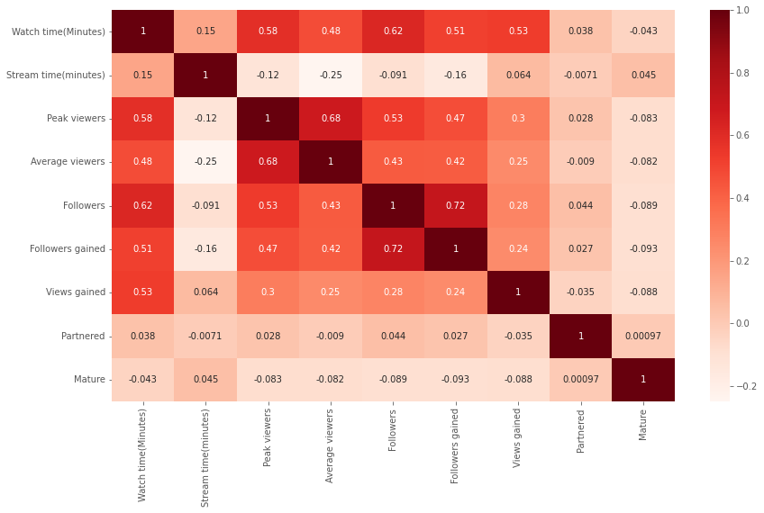

```python
plt.figure(figsize=(14, 8))
sns.heatmap(data.corr(), annot=True, cmap='Reds')
plt.show()
```

Before begininng our analysis we wanted to get an overall sense of the variables and how they relate with eachother. We determined that the best way to visualize this would be through a heat map. In our heat map above we can observe that variables with a darker color represent a higher correlation. Obviously variables will have a magnitude of 1 with itself, but along with that we can observe how other variables interact with eachother. The darker the square indicated to us that it would be useful to observe the relationship between the two variables in some sort of way later on in our analysis. For instance followers and total watch time was found to have a high magnitude along with average viewers and watch time. Certain boxes of the heat map weren't that useful such as the magnitude between average viewers and peak viewers which you would expect to have a high magnitude. However all in all the heat map was a very useful tool in getting us started with deciding what visualizations we want to make and what relationships we wanted to graph.

## Top 25 Streamers vs...

### Top 25 Streamers vs Stream Time:

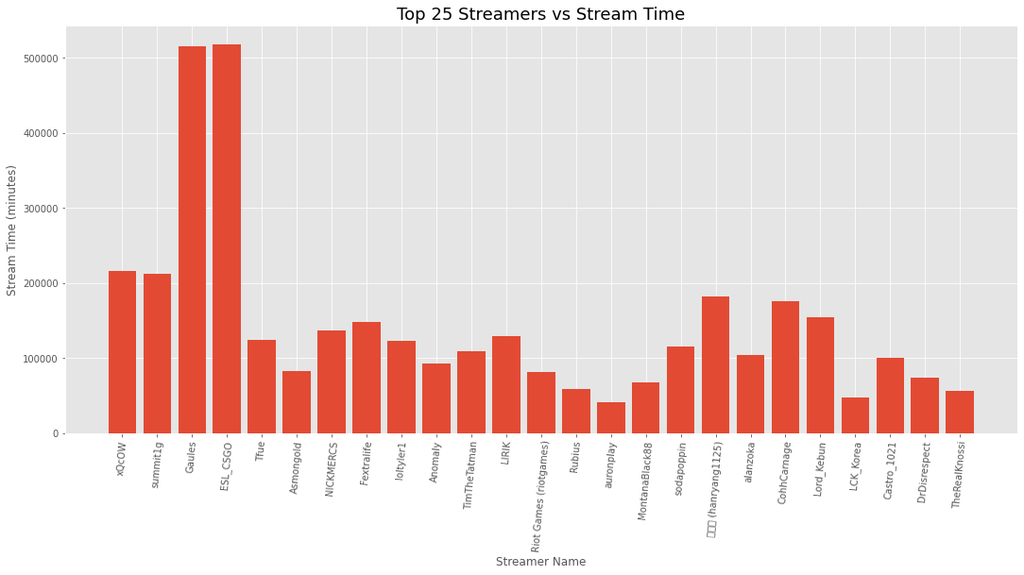

```python
fig = plt.figure(figsize=(14, 6))
ax = fig.add_axes([0,0,1,1])
mins = list(data['Stream time(minutes)'])
channel = list(data['Channel'])

plt.title('Top 25 Streamers vs Stream Time', fontsize=18)
ax.set_ylabel("Stream Time (minutes)")
ax.set_xlabel("Streamer Name")
ax.bar(channel[:25], mins[:25])
for tick in ax.get_xticklabels():
    tick.set_rotation(85)
plt.show()
```

### Top 25 Streamers vs. Views Gained

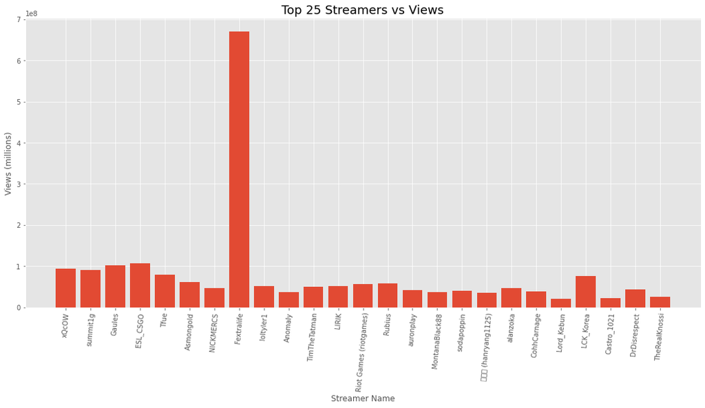

```python
fig = plt.figure(figsize=(14, 6))
ax = fig.add_axes([0,0,1,1])
mins = list(data['Views gained'])
channel = list(data['Channel'])

plt.title('Top 25 Streamers vs Views',fontsize=18)
ax.set_ylabel("Views (millions)")
ax.set_xlabel("Streamer Name")
ax.bar(channel[:25], mins[:25])
for tick in ax.get_xticklabels():
    tick.set_rotation(85)
plt.show()
```

### Top 25 Streamers vs. Followers

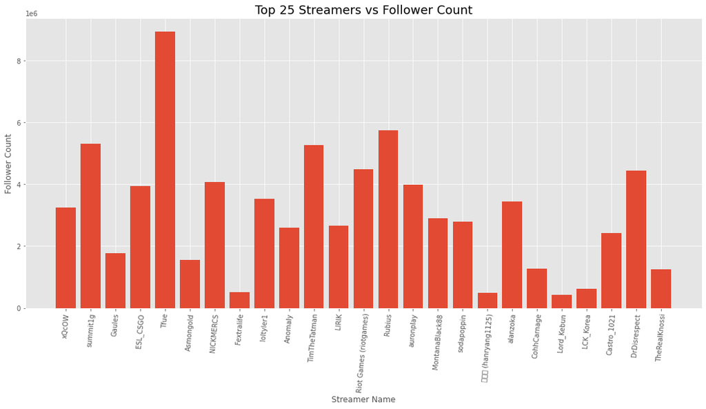

```python
fig = plt.figure(figsize=(14, 6))
ax = fig.add_axes([0,0,1,1])
mins = list(data['Followers'])
channel = list(data['Channel'])

plt.title('Top 25 Streamers vs Follower Count',fontsize=18)
ax.set_ylabel("Follower Count")
ax.set_xlabel("Streamer Name")
ax.bar(channel[:25], mins[:25])
for tick in ax.get_xticklabels():
    tick.set_rotation(85)
plt.show()
```

Continuing our analysis regarding the top 25 Twitch streamers we now created a visualization to provide an analysis on the relationship between the top 25 streamers and the number of followers they have. As in our previous 2 cases we see that there doesn't seem to be a trend in number of followers a streamer has and their ranking. Although streamer 'Tfue' is largely popular with the most followers having over 8 million followers, streameer 'xQcOW' is the top streamer and has under 4 million followers. Thus just because a streamer has a high following it doesn't guarantee a high watch rate.

## Looking at the Top 10 Streamers

Our first graph will be a pie chart looking at the top 10 Twitch streamers determined by their followers. We'll use a pie graph in order to visualize the percentage of followers each streamer has out of the top 10.

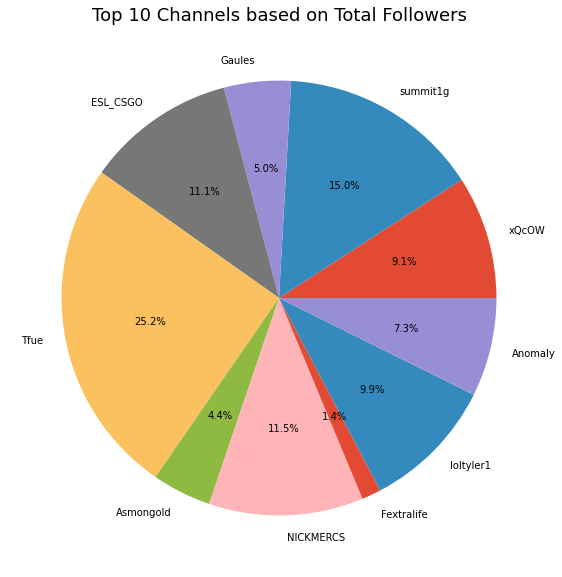

```python
plt.figure(figsize=(10,10))
plt.title('Top 10 Channels based on Total Followers', fontsize=18)
followers = list(data["Followers"])[:10]
channels = list(data["Channel"])[:10]
plt.pie(followers, labels=channels, autopct='%1.1f%%')
plt.show()
```

Our second graph will be a pie chart looking at the top 10 Twitch streamers determined by their average viewers. We'll use a pie graph in order to visualize the percentage of viewers each streamer has out of the top 10.

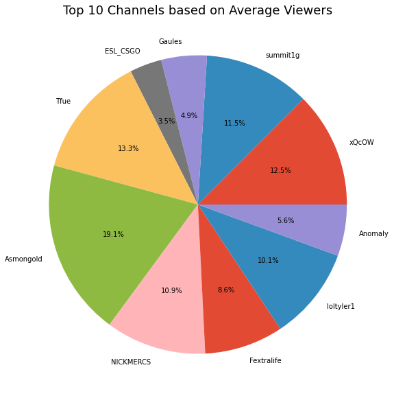

```python
plt.figure(figsize=(10,10))
plt.title('Top 10 Channels based on Average Viewers', fontsize=18)
avg = list(data["Average viewers"])[:10]
channels = list(data["Channel"])[:10]
plt.pie(avg, explode=None, labels=channels, autopct='%1.1f%%')
plt.show()
```

Between the two pie charts we can observe that just because a streamer has a high following count it doeesn't imply that the streamer will have a higher average number of viewers. For instance in graph 1 streamer "Asmongold" only made up 4.4% of the pie chart based on his followers but when we jump to graph 2 we see that "Asmongold" takes up the largest proportion of the graph at 19.1% based on his average views. The oopsoite scenario can be seen with streamer "ESL_CSGO" who went from 11.1% in the followers graph to only 3.5% in the number of views graph. These cases along with others shows us that having high followers doesn't guarantee high views and vice versa.

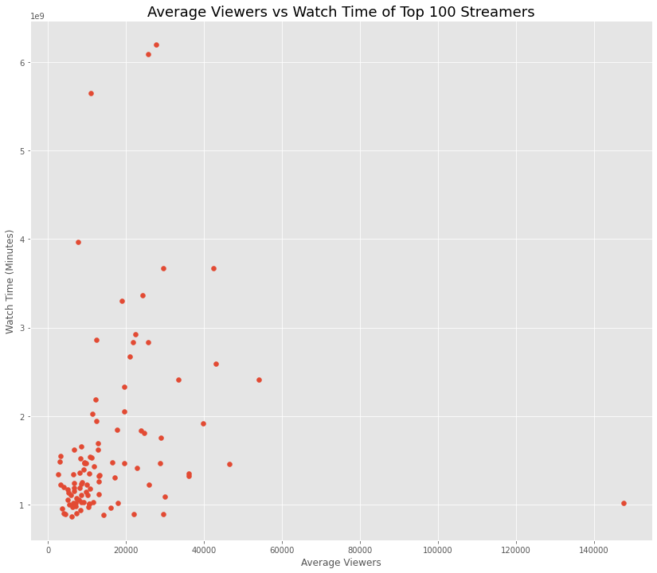

```python
top100 = data[:100]
avgviewers = top100["Average viewers"]
watch = top100["Watch time(Minutes)"]
plt.figure(figsize=(14, 12))
plt.scatter(avgviewers, watch)
plt.title("Average Viewers vs Watch Time of Top 100 Streamers", fontsize=18)
plt.xlabel("Average Viewers")
plt.ylabel("Watch Time (Minutes)")
plt.show()
```

The scatter plot above visualizes the relationship between average viewers vs total watch time of the top 100 Twitch streamers. In our plot we can see that the plots are highly concentrated in the bottom left implying that often the views and watch time are concentrated in one area. We do have a few outliers but in general the plots are in one area.

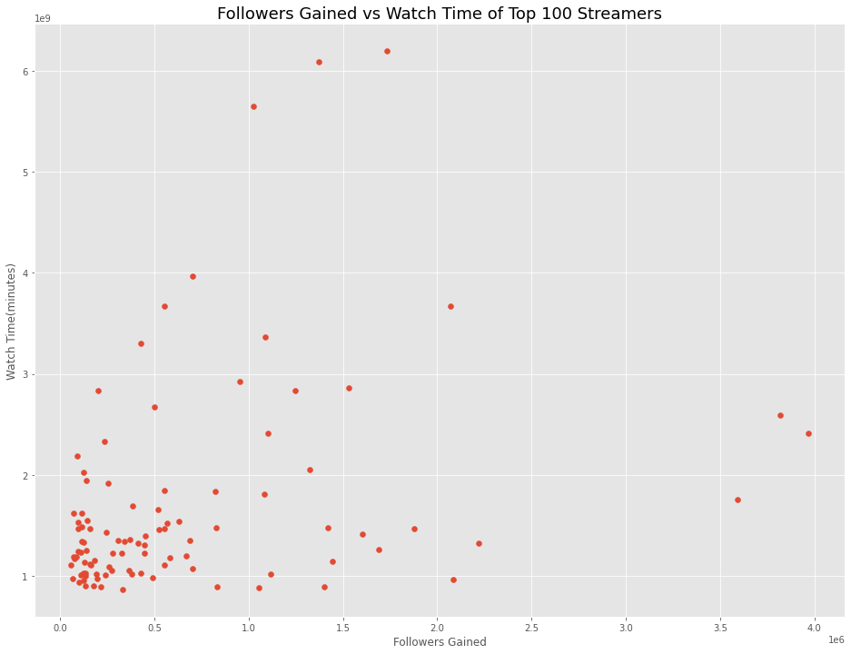

```python
top100 = data[:100]
followers_gained = top100["Followers gained"]
watch = top100["Watch time(Minutes)"]
plt.figure(figsize=(16, 12))
plt.scatter(followers_gained, watch)
plt.title("Followers Gained vs Watch Time of Top 100 Streamers", fontsize=18)
plt.xlabel("Followers Gained")
plt.ylabel("Watch Time(minutes)")
plt.show()
```

The scatter plot above visualizes the relationship between followers gained total watch time of the top 100 Twitch streamers. In our plot we can see that the plots are mostly concentrated in the bottom left implying that often the followers gained and watch time are concentrated in one area. The data does appear to be more spread out than our previous plot so the relationship isn't as strong.

## Bottom 100 Streamers

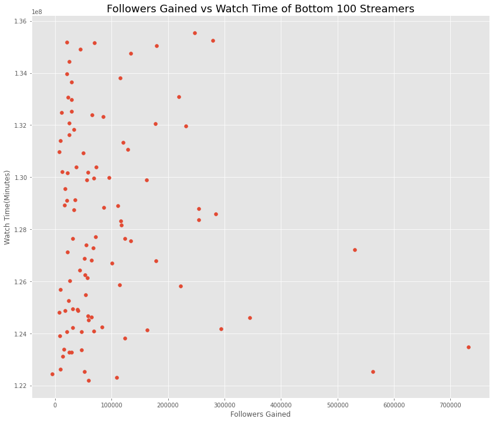

```python
bottom100 = data[-100:]
followers_gained = bottom100["Followers gained"]
watch = bottom100["Watch time(Minutes)"]
plt.figure(figsize=(14, 12))
plt.scatter(followers_gained, watch)
plt.title("Followers Gained vs Watch Time of Bottom 100 Streamers", fontsize=18)
plt.xlabel("Followers Gained")
plt.ylabel("Watch Time(Minutes)")
plt.show()
```

The scatter plot above visualizes the relationship between followers gained and watch time of the bottom 100 streamers. In this plot we can see a huge difference with the data values when compared to the scatter plots of the Top 100 streamers. The bottom 100 streamers have most of the followers gained concentrated in the lower numbers however their watch time is all over the place. The data points are scattered up and down showcasing no clear relationship between the followers and watch time for the bottom 100 streamers, rather it all just seems much more random. We can also see a change in the y-axis in that the bottom 100 streamers have a lower range of values for watch time.

## Linear Regression of All Streamers

For our last visualization our goal was to create a linear regression to predict the watch time of a streamer based on the number of followers they had.

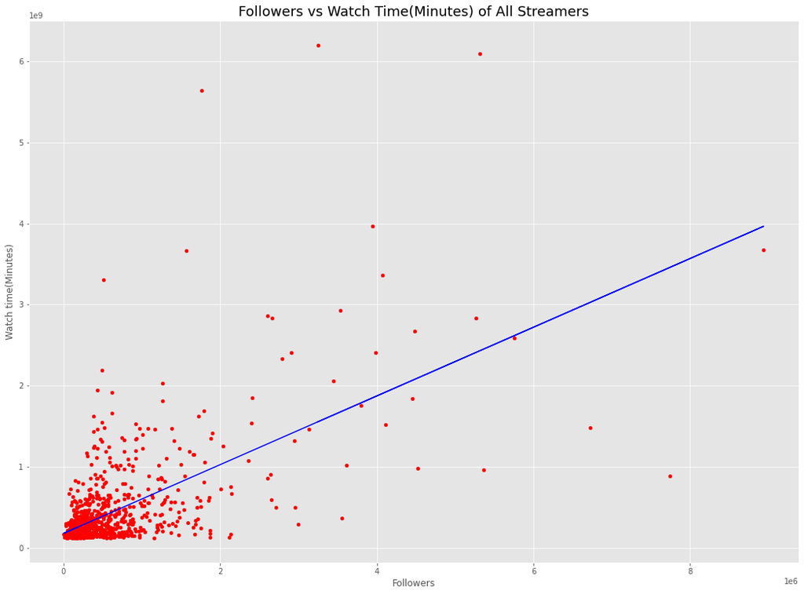

```python
def get_regression_model(df, x, y):
   model = LinearRegression()
   X = [[x] for x in df[x].values]
   y = [[y] for y in df[y].values]
   rfit = model.fit(X, y)
   rscore = model.score(X, y)
   return model, rfit, rscore

unique_f = [[x] for x in data['Followers'].unique()]
model, rfit, rscore = get_regression_model(data, 'Followers', 'Watch time(Minutes)')
ax = data.plot('Followers', 'Watch time(Minutes)', kind='scatter', c='r', figsize=(18, 13))
ax.set_title('Followers vs Watch Time(Minutes) of All Streamers', fontsize=18)
ax.plot(unique_f, [y for [y] in model.predict(unique_f)], c='blue')
plt.show()
```

```python
# must rename columns for formula to work in ols function
data.rename(columns={"Watch time(Minutes)": "watch_time", "Peak viewers": "peak_viewers"}, inplace=True)
coef = rfit.coef_[0]
intercept = rfit.intercept_
print("Coefficient: ", coef)
print("Intercept: ", intercept)
print("R^2: ", rscore)
print("\ny = mx + b")
print(f"watch_time = {rfit.coef_[0]}(Followers) + {rfit.intercept_}")
regr_inter = smf.ols(formula = "watch_time ~ Followers", data = data).fit()
regr_inter.summary()
```

```
Coefficient:  [423.7902838]
Intercept:  [1.76844555e+08]
R^2:  0.38469007014437984

y = mx + b
watch_time = [423.7902838](Followers) + [1.76844555e+08]
```

OLS Regression Results

| Dep. Variable: | watch_time | R-squared: | 0.385 |
| --- | --- | --- | --- |
| Model: | OLS | Adj. R-squared: | 0.384 |
| Method: | Least Squares | F-statistic: | 623.9 |
| Date: | Mon, 20 Dec 2021 | Prob (F-statistic): | 2.33e-107 |
| Time: | 12:27:38 | Log-Likelihood: | -21300. |
| No. Observations: | 1000 | AIC: | 4.260e+04 |
| Df Residuals: | 998 | BIC: | 4.261e+04 |
| Df Model: | 1 |  |  |
| Covariance Type: | nonrobust |  |  |

|  | coef | std err | t | P>\|t\| | [0.025 | 0.975] |
| --- | --- | --- | --- | --- | --- | --- |
| Intercept | 1.768e+08 | 1.67e+07 | 10.576 | 0.000 | 1.44e+08 | 2.1e+08 |
| Followers | 423.7903 | 16.966 | 24.979 | 0.000 | 390.497 | 457.083 |

| Omnibus: | 946.871 | Durbin-Watson: | 0.841 |
| --- | --- | --- | --- |
| Prob(Omnibus): | 0.000 | Jarque-Bera (JB): | 65254.924 |
| Skew: | 4.130 | Prob(JB): | 0.00 |
| Kurtosis: | 41.703 | Cond. No. | 1.21e+06 |

Notes:  
[1] Standard Errors assume that the covariance matrix of the errors is correctly specified.  
[2] The condition number is large, 1.21e+06. This might indicate that there are  
strong multicollinearity or other numerical problems.

## **Conclusion**

In this tutorial, we wanted to analyze the dataset of the top 1000 Twitch streamers around the world. Analyzing the information we got from the dataset along with visual representations of it allowed us to dive deeper into the correlation between different variables and if it helps a streamer become a top streamer. From this, we discovered that for the top 10 streamers just because a streamer has a high number of followers doesn't equate to them having a high watch time. Often time streamers with lower follower counts would have greater total watch time than streamers with much more followers. This allows streamers to know that just because their follower count isn't as high as others they shouldn't be discouraged and that they can still become a top streamer based on total watch time. We also saw that in the top 25 streamers a high follower count or high number of views didn't seem to equate to being a more popular streamer. This again lets individuals know they shouldn't be discouraged if their number of followers isn't high, their watch time can still be high and they can still be a top streamer. We then looked at the top 100 and the bottom 100 streamers and saw that in the top 100 streamers followers and watch time were concentrated in one area whereas for the bottom 100 the watch time was all over the place. In the end we performed a linear regression between followers and watch time to see if we could find a relationship. We saw that there was a positive trend between followers and a streamers watch time however the correlation was somewhat low with r-squared value being a 0.385. The linear regression did lead us to conclude that there is somewhat of a small correlation and that as your number of followers increase your watch time should increase as well.

The data that we analyzed helped us have a better understanding about what really makes a twitch streamer be in the top percentile. Based on the analysis of each subcategory, some streamers had a lot more average viewers, some streamers had a lot more average watch time ,and some had a lot more followers than other. All of this information helped us determine that to be a top streamer, there are a variety of different factors that come into play and no one should be discouraged if they are lacking in one category.